# Distribuições de Poisson e binomial negativa

Gabriela Neres, Mariane Melo, Pedro Lopes

## 1 Introdução

Apesar do estigma de pouco biodiversos, rios intermitentes são capazes de manter sua biodiversidade mesmo em períodos sem fluxo, quando se formam poças que acumulam água, salvaguardando as espécies localmente.

Neste exercício vamos analisar como o tamanho da poça influencia o número de espécies encontradas. Como o número de espécies normalmente cresce de forma não linear ao tamanho da região amostrada (relação espécies-área; Rosenzweig, 1999), vamos utilizar funções suavizantes em modelos GAM.

## 2 Carregando os pacotes

```r
library(mgcv) #rodar gam
library(mgcViz) #visualizar resultados do gam
library(gratia) #visualizar resultados do gam
library(tidyverse) #visualização e manipulação de dados
library(DHARMa) #avaliação dos residuos
library(performance) #avaliação dos residuos
library(sjPlot) #efeitos condicionais
library(GGally) # Análise exploratória
library(MASS) # modelo binomial negativo
library(AICcmodavg) # Tabelas AICc
```

## 3 Carregando os dados

```r
data <- read.csv("dados_p2.csv")

glimpse(data)
```

```
## Rows: 12
## Columns: 4
## $ id_site  <chr> "P1", "P2", "P3", "P4", "P5", "P6", "P7", "P8", "P9", "P10", …
## $ richness <int> 13, 13, 12, 3, 9, 2, 2, 4, 3, 2, 3, 2
## $ Area     <dbl> 2474.200000, 130.676000, 276.184000, 149.353333, 318.792000, …
## $ Vol      <dbl> 784.0121250, 49.7657767, 86.4801150, 41.1788476, 103.2886080,…
```

id_site: id do local de coleta; richness: riqueza de peixes; Area: área da poça (m2), Vol: volume de água da poça (m3).

## 4 Análise exploratória

```r
ggpairs(data[, -1])
```

[figure not shown]

## 5 Modelo linear

Vamos começar ajustando modelos lineares, usando apenas área e volume como preditores para ver qual se ajusta melhor.

```r
m.poi.area <- glm(richness ~ Area, data = data, family = poisson(link = "log"))
check_overdispersion(m.poi.area)
```

```
## # Overdispersion test
##
##        dispersion ratio =   3.253
##   Pearson's Chi-Squared =  32.526
##                 p-value = < 0.001
```

```r
check_model(m.poi.area)
```

[figure not shown]

```r
m.neg.area <- glm.nb(richness ~ Area, data = data)
check_overdispersion(m.neg.area)
```

```
## # Overdispersion test
##
##  dispersion ratio = 0.955
##           p-value = 0.784
```

```r
check_model(m.neg.area)
```

[figure not shown]

```r
m.poi.vol <- glm(richness ~ Vol, data = data, family = poisson(link = "log"))
check_overdispersion(m.poi.vol)
```

```
## # Overdispersion test
##
##        dispersion ratio =   3.222
##   Pearson's Chi-Squared =  32.221
##                 p-value = < 0.001
```

```r
check_model(m.poi.vol)
```

[figure not shown]

```r
m.neg.vol <- glm.nb(richness ~ Vol, data = data)
check_overdispersion(m.neg.vol)
```

```
## # Overdispersion test
##
##  dispersion ratio = 0.961
##           p-value = 0.712
```

```r
check_model(m.neg.vol)
```

[figure not shown]

Para ambas as variáveis, o modelo binomial negativo se ajusta melhor e corrige a sobredispersão encontrada. Há uma poça muito maior com as outras, se apresentando como um outlier. Vamos transformar em log e prosseguir com a distribuição binomial negativa, e ver se o volume ou a área se ajustam melhor. Usamos o critério de akaike corrigido para amostras pequenas (AICc).

```r
m.neg.area.l <- glm.nb(richness ~ log(Area), data = data)
check_overdispersion(m.neg.area.l)
```

```
## # Overdispersion test
##
##  dispersion ratio = 1.048
##           p-value = 0.752
```

```r
check_model(m.neg.area.l)
```

[figure not shown]

```r
m.neg.vol.l <- glm.nb(richness ~ log(Vol), data = data)
check_overdispersion(m.neg.vol.l)
```

```
## # Overdispersion test
##
##  dispersion ratio = 1.098
##           p-value = 0.656
```

```r
check_model(m.neg.vol.l)
```

[figure not shown]

```r
aictab(list(m.neg.area, m.neg.vol, m.neg.area.l, m.neg.vol.l), second.ord = T)
```

```
##
## Model selection based on AICc:
##
##      K  AICc Delta_AICc AICcWt Cum.Wt     LL
## Mod4 3 62.35       0.00   0.72   0.72 -26.68
## Mod3 3 64.43       2.08   0.25   0.97 -27.71
## Mod2 3 70.17       7.82   0.01   0.99 -30.59
## Mod1 3 70.35       8.00   0.01   1.00 -30.68
```

De acordo acordo com o AICc, o melhor modelo é aquele utilizando distribuição binomial negativa, com volume transformado na escala log. Vamos visualizar o efeito agora.

```r
summary(m.neg.vol.l)
```

```
##
## Call:
## glm.nb(formula = richness ~ log(Vol), data = data, init.theta = 25.16939542,
##     link = log)
##
## Coefficients:
##             Estimate Std. Error z value Pr(>|z|)
## (Intercept)  0.85808    0.27134   3.162  0.00156 **
## log(Vol)     0.27515    0.06478   4.247 2.16e-05 ***
## ---
## Signif. codes:  0 '***' 0.001 '**' 0.01 '*' 0.05 '.' 0.1 ' ' 1
##
## (Dispersion parameter for Negative Binomial(25.1694) family taken to be 1)
##
##     Null deviance: 31.185  on 11  degrees of freedom
## Residual deviance: 11.102  on 10  degrees of freedom
## AIC: 59.352
##
## Number of Fisher Scoring iterations: 1
##
##
##               Theta:  25.2
##           Std. Err.:  55.1
##
##  2 x log-likelihood:  -53.352
```

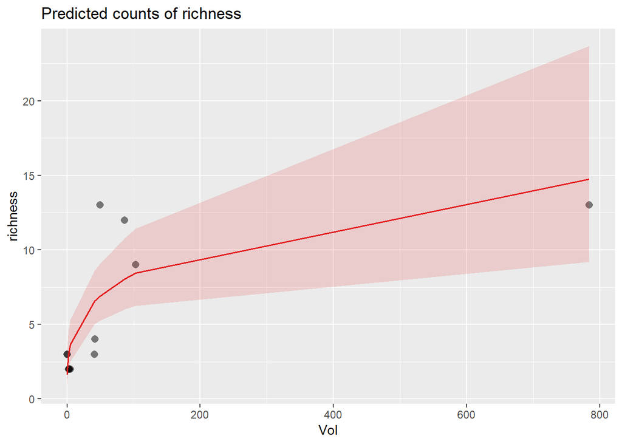

```r
plot_model(m.neg.vol.l, type = "pred", terms = "Vol", show.data = T)
```

## 6 Modelo GAM

Vamos ajustar agora um modelo GAM e ver se ele explica melhor nossos dados!

```r
m.gam <- gam(richness ~ s(log(Vol), bs = "cr"), data = data, family = nb)
check_overdispersion(m.gam)
```

```
## # Overdispersion test
##
##  dispersion ratio = 0.809
##           p-value =  0.96
```

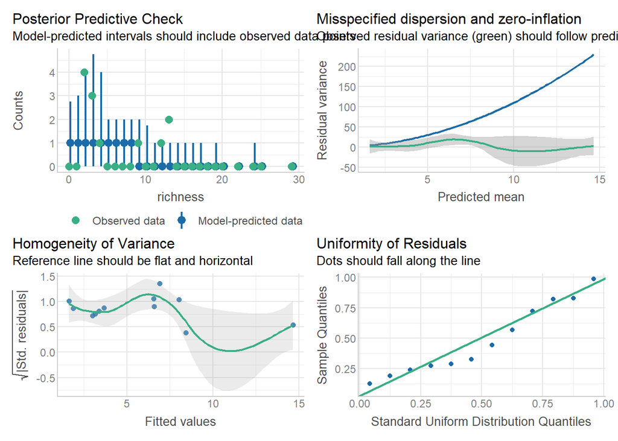

```r
check_model(m.gam)
```

```r
summary(m.gam)
```

```
##
## Family: Negative Binomial(11.831)
## Link function: log
##
## Formula:
## richness ~ s(log(Vol), bs = "cr")
##
## Parametric coefficients:
##             Estimate Std. Error z value Pr(>|z|)
## (Intercept)    1.539      0.168   9.162   <2e-16 ***
## ---
## Signif. codes:  0 '***' 0.001 '**' 0.01 '*' 0.05 '.' 0.1 ' ' 1
##
## Approximate significance of smooth terms:
##             edf Ref.df Chi.sq  p-value
## s(log(Vol))   1      1  14.71 0.000125 ***
## ---
## Signif. codes:  0 '***' 0.001 '**' 0.01 '*' 0.05 '.' 0.1 ' ' 1
##
## R-sq.(adj) =  0.602   Deviance explained = 64.1%
## -REML =  27.43  Scale est. = 1         n = 12
```

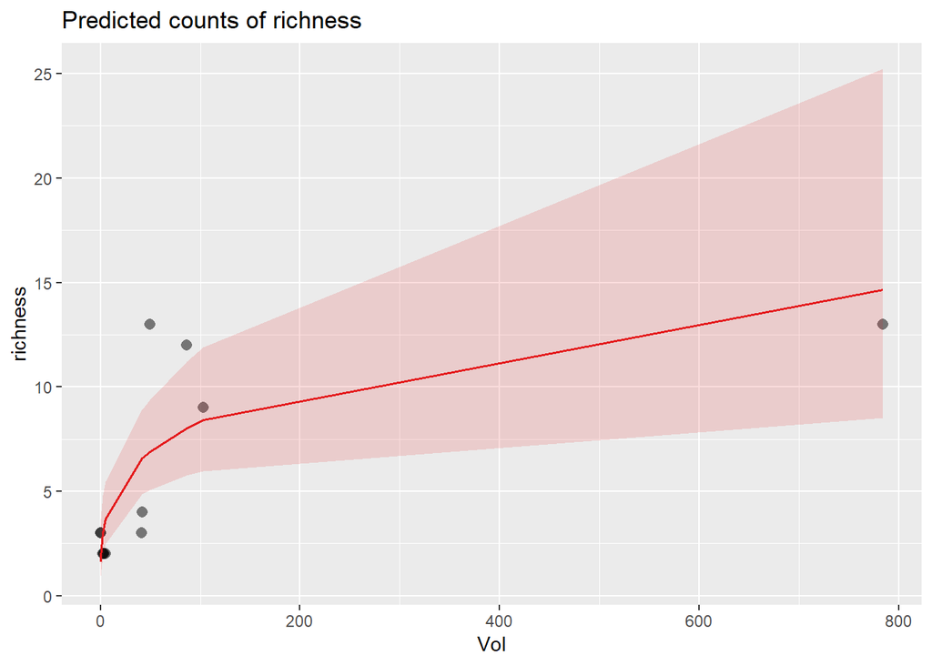

```r
plot_model(m.gam, type = "pred", terms = "Vol", show.data = T)
```

O ajuste e os resultados são idênticos na prática. Isto significa que o modelo GAM não detectou não-linearidade nos dados para o volume logaritimizado. Pelo princípio da parcimônia, podemos nos ater ao modelo linear. Entretanto, para fins deste exercício, vamos estimar agora quantas espécies ganhamos por acréscimo de volume.

```r
(vol0 <- predict(m.gam, newdata = list(Vol = 10), type = "response"))
```

```
##        1
## 4.447631
```

```r
(vol1 <- predict(m.gam, newdata = list(Vol = 21), type = "response"))
```

```
##        1
## 5.448429
```

```r
(vol2 <- predict(m.gam, newdata = list(Vol = 600), type = "response"))
```

```
##       1
## 13.6314
```

```r
(vol3 <- predict(m.gam, newdata = list(Vol = 784.0121), type = "response"))
```

```
##        1
## 14.66624
```

No começo da curva, ganhamos uma espécie a cada cerca de 11m3 a mais de água. No final da curva, entretanto, é preciso aumentar quase 200m3 de água para ganharmos mais uma espécie.

## 7 Conclusão

O modelo binomial negativo e GAM tiveram ajustes semelhantes. Conseguimos modelar o número de espécies em função do volume da poça, e encontramos uma relação de platô, com um grande aumento no número de espécie para pequenos volumes de água, e um pequeno aumento para grandes volumes.